# 공간통계를 위한 데이터 사이언스

지리정보 - R

xwMOOC

Tidyverse Korea

2019-03-12

# 1 지리정보 파일 [^1] [^2]

전통적으로 지리정보는 `.shp` 확장자명을 갖는 ESRI Shapefile에 저장을 했다. `*.shp`, `*.dbf`, `*.shx` 파일이 나눠서 저장되어 있다. 이로 인해서 ESRI Shapefile 지도정보 파일은 디렉토리에 담겨지게 된다.

- `*.shp`: `geometry` 정보(점, 선, 다각형)
- `*.dbf`: 각 `geometry`에 대한 속성정보 저장
- `*.shx`: `geometry`와 속성(attributes) 정보 연결
- `*.prj`: 좌표계 정보 저장

R 에서 ESRI Shapefile 파일을 저장하면 S4 `SpatailPolygonsDataFrame`으로 저장된다. 따라서, 점/선/다각형이 담긴 `geometry`와 데이터프레임이 연결되어 저장되어 있다.

실제 세상을 지도로 표현함에 있어 두가지 방식을 사용한다. 하나는 벡터(vector)로 표현하는 것이고 `OGR`을 사용하고, 또 다른 하나는 격자(Grid), 래스터(raster)로 표현하는 것으로 `GDAL`을 아래에 각각 깔고 R로 불러와서 사용하게 된다.

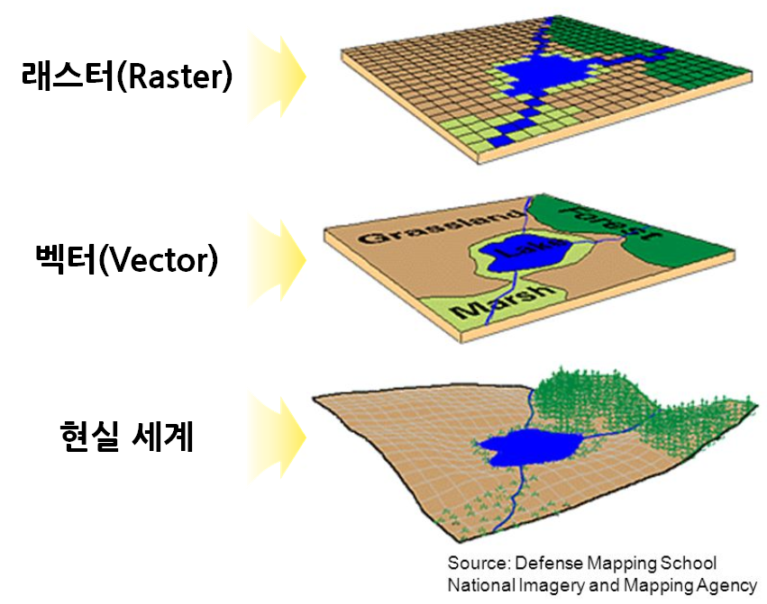

# 2 좌표계(CRS) [^3] [^4]

좌표계(CRS, Coordinate Reference System)는 둥근 지구를 2차원 평면에 투영(projection)하는 다양한 방법을 지칭한다. 좌표계를 제작할 때 각기 다른 목적에 맞춰 제작되었기 때문에 지리정보를 활용함에 있어 적절한 좌표계를 채택하여활용하는 것이 중요하다. 많이 사용되는 좌표계는 다음이 있다. WGS84(WGS 1984, EPSG:4326, WGS84)는 세계 지구 좌표 시스템(World Geodetic System, WGS) 1984년에 제정된 범 지구적 측위 시스템으로 지도학, 측지학, 항법에 많이 사용된다.

- **EPSG:4326** → WGS84 경위도: GPS가 사용하는 좌표계
  - 서비스: 구글 지구(Google Earth)
  - 단위: 소수점 (decimal degrees)
  - `+proj=longlat +ellps=WGS84 +datum=WGS84 +no_defs`
- **EPSG:3857** → Google Mercator
  - 서비스: 구글 지도(Google Maps), 빙 지도(Bing Maps), 야후지도, OSM(Open Street Maps)
  - 단위: 미터
  - `+proj=merc +a=6378137 +b=6378137 +lat_ts=0.0 +lon_0=0.0 +x_0=0.0 +y_0=0 +k=1.0 +units=m +nadgrids=@null +no_defs`
- **EPSG:5181** → 중부원점(GRS80)
  - 서비스: 다음카카오 지도 API [^5]
  - CRS 스펙: `+proj=tmerc +lat_0=38 +lon_0=127 +k=1 +x_0=200000 +y_0=500000 +ellps=GRS80 +units=m +no_defs`
- **EPSG:5179** → UTM-K (GRS80) [^6]
  - 서비스: 네이버지도
  - CRS 스펙: `+proj=tmerc +lat_0=38 +lon_0=127.5 +k=0.9996 +x_0=1000000 +y_0=2000000 +ellps=GRS80 +units=m +no_defs`
- **EPSG:5178** → UTM-K (Bessel)
  - 서비스: 새주소지도
  - CRS 스펙: `+proj=tmerc +lat_0=38 +lon_0=127.5 +k=0.9996 +x_0=1000000 +y_0=2000000 +ellps=bessel +units=m +no_defs +towgs84=-145.907,505.034,685.756,-1.162,2.347,1.592,6.342`

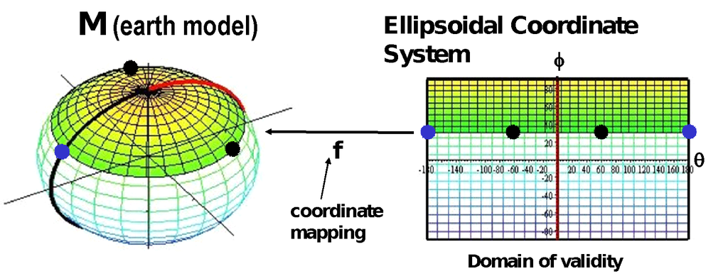

# 3 R 팩키지

- 공간 데이터
  - `sp`: [sp: Classes and Methods for Spatial Data](https://cran.r-project.org/web/packages/sp/index.html)
  - `sf`: [sf](https://cran.r-project.org/web/packages/sf/index.html)
    - ‘GDAL’: 데이터를 불러오고 저장.
    - ‘GEOS’: geometry 연산작업
    - ‘PROJ’: 좌표계 변환(projection conversions and datum transformations)
  - `stars`: [Spatiotemporal tidy arrays for R](https://github.com/r-spatial/stars)
- 정적 시각화
  - `ggmap`: [ggmap: Spatial Visualization with ggplot2](https://cran.r-project.org/web/packages/ggmap/index.html)
- 인터랙티브 시각화
  - `leaflet`: [Open-source JavaScript libraries for interactive maps](https://rstudio.github.io/leaflet/)
  - `tmap`: [tmap: Thematic Maps](https://github.com/mtennekes/tmap)
  - `mapview`: [mapview: Interactive Viewing of Spatial Data in R](https://github.com/r-spatial/mapview)

**`sp` - `sf` 이전 시절**

`sp`, `rgdal`, `rgeos`를 결합하여 사용하던 옛시절이 있었다.

- `sp`: 벡터 혹은 래스터 공간정보 데이터를 다루기 위한 기본 자료구조.
- `rgdal`: `GDAL`/`OGR`을 바탕으로 공간데이터를 불러오고 저장하는 역할을 담당.
- `rgeos`: 파이썬 `shapely`처럼 `GEOS`를 바탕으로 다양한 `geometry` 연산작업을 수행(`union`, `intersections`, `buffer` 등).

**`sf` 통일 시대**

- 실세계에서 객체가 어떻게 표현되어야 하는지를 모사하는 `ISO 19125-1:2004` 표준 **`Simple Feature`**를 충실히 따름.
- `sf`의 기본은 데이터프레임
- `sp`, `rgdal`, `rgeos` 팩키지 모든 기능을 `sf` 하나에 담아냄.
- `sp`, `rgdal` 보다 설치하기 쉽고 훨씬 더 빠르고 확장성이 뛰어남.

# 4 지도 데이터

- `GADM`: [GADM maps and data](https://gadm.org/)
  - level-0, level-1, level-2
  - Geopackage
  - Shapefile
  - R (`sp`)
  - R (`sf`)
- `tigris`: [Census TIGER/Line shapefiles](https://github.com/walkerke/tigris)
- `rworldmap`: [Mapping Global Data](https://github.com/AndySouth/rworldmap)
- [대한민국 최신 행정구역(SHP) 다운로드](http://www.gisdeveloper.co.kr/?p=2332): 시도, 시군구, 읍면동, 리
- [대한민국 행정동 경계(admdongkor)](https://github.com/vuski/admdongkor)
  - `geojson` 파일형식, 좌표계는 WGS84 (EPSG:4326), 인코딩 UTF-8.
- [국토정보플랫폼 - 국토교통부 국토지리정보원 운영](http://map.ngii.go.kr/mn/mainPage.do)

## 4.1 `GADM` 지도 데이터

[Download GADM data (version 3.6)](https://gadm.org/download_country_v3.html) 웹사이트에서 레벨2(level-2)까지 시군구 데이터를 불러온다. `sf` 팩키지로 바로 작업할 수 있도록 `R (sf)` **level2**를 다운로드 받아 시각화한다.

- R (sf): level-0, level1, **level2**

```r
library(tidyverse)
library(sf)

korea_sf <- read_rds("data/shapefile/gadm36_KOR_2_sf.rds")

st_crs(korea_sf)

head(korea_sf)

korea_sf %>%
  select(GID_0) %>%
  plot()
```

[output not shown]

# 5 행정동 전체코드 [^7]

“행정표준코드관리시스템” → 자주묻는질문 → 게시판글 1번: "  
행정동코드(전체) 및 법정동·행정동코드 매핑 자료 받는 방법은 어떻게 되나요?"

지도관련하여 주무관청이 다르고 서로 추구하는 바도 달라 동일한 지도위에 서로 다른 코드를 정해 사용하고 있다. 과거에는 서로 교차업무를 할 일이 없어 독립적인 코드체계가 그다지 문제가 되지 않았으나, 오늘날에는 코딩 작업하는 개발자에게 커다란 고통을 수반하고 있다. 크게 통계청과 행정안전부로 나눠 살펴볼 수 있다.

[통계청](http://kostat.go.kr/) → [통계분류포털](http://kssc.kostat.go.kr) 사이트에서,  
즉, `통계청` → `통계분류포털` → `특수/일반/국제/행정구역분류`를 쫓아가게 되면, [한국행정구역분류](https://kssc.kostat.go.kr:8443/ksscNew_web/index.jsp)에서 대한 엑셀파일을 다운로드 받거나 웹화면으로 조회를 할 수도 있다. 결국 `.shp` 파일에 내재되어 있는 행정동 정보와 행정구역코드를 시도, 시군구, 읍면동으로 구분해 나갈 수 있다.

행정안전부 행정동 전체 코드의 경우, 행정동 전체코드 및 법정동·행정동코드 매핑 자료는 행정안전부 지방행정실 홈페이지에서 자료를 제공하고 있다. [^8]

좌측 메뉴에서 “지방자치분권실” → “주민등록 및 인감” → “주민등록 및 인감” 을 따라 ’주민등록 및 인감 게시판’에서 ’주민등록주소코드 변경내역의 최신일자’로 된 제목을 클릭하여 압축파일을 다운로드한다.

압축해제하게 되면 다음과 같은 형식의 파일이 압축이 풀려 디렉토리에 저장된다.

- KiKcd_H.20140301(날짜) - 행정기관코드(전제 행정동코드)
- KiKcd_B.20140301(날짜) - 법정주소코드(전체 법정동코드)
- KiKmix.20140301(날짜) - 행정기관코드+법정주소코드(매핑코드)

주민등록주소코드 변경내역(2019.03.01. 시행) `jscode20190301.zip` 파일을 압축풀게 되면 `KIKcd_H.20190301.xlsx` 파일이 행정동 기준으로 나온다. 이를 활용하여 행정동코드를 확인할 수 있고 앞서 [대한민국 최신 행정구역(SHP) 다운로드](http://www.gisdeveloper.co.kr/?p=2332)에서 내려받은 `shapefile`과 연결하여 수월(?)하게 공간정보 관련 작업을 수행할 수 있게 된다.

```r
library(readxl)

h_code_df <- read_excel("data/shapefile/jscode20190301/KIKcd_H.20190301.xlsx", sheet='KIKcd_H')

DT::datatable(h_code_df)
```

|  | 행정동코드 | 시도명 | 시군구명 | 읍면동명 | 생성일자 | 말소일자 |
| --- | --- | --- | --- | --- | --- | --- |
| 1 | 1100000000 | 서울특별시 |  |  | 19880423 |  |
| 2 | 1111000000 | 서울특별시 | 종로구 |  | 19880423 |  |
| 3 | 1111051500 | 서울특별시 | 종로구 | 청운효자동 | 20081101 |  |
| 4 | 1111053000 | 서울특별시 | 종로구 | 사직동 | 19880423 |  |
| 5 | 1111054000 | 서울특별시 | 종로구 | 삼청동 | 19880423 |  |
| 6 | 1111055000 | 서울특별시 | 종로구 | 부암동 | 19880423 |  |
| 7 | 1111056000 | 서울특별시 | 종로구 | 평창동 | 19880423 |  |
| 8 | 1111057000 | 서울특별시 | 종로구 | 무악동 | 19880423 |  |
| 9 | 1111058000 | 서울특별시 | 종로구 | 교남동 | 19880423 |  |
| 10 | 1111060000 | 서울특별시 | 종로구 | 가회동 | 19880423 |  |

[output cut: 3854 more lines]

[^1]: [Data Carpentry, “Introduction to Geospatial Raster and Vector Data with R”](https://datacarpentry.org/r-raster-vector-geospatial/)
[^2]: [Justina Hensley, “Spatial data models (types)”](https://slideplayer.com/slide/6152526/)
[^3]: [OSGeo(Open Source GeoSpatial) 한국어 지부 - OSGeo Korean Chapter, “한국 주요 좌표계 EPSG코드 및 proj4 인자 정리”“](https://www.osgeo.kr/17)
[^4]: [Wolfgang SCHEUCHER (Solitec), “Coordinate Reference System”](https://ext.eurocontrol.int/aixm_confluence/display/ACG/Coordinate+Reference+System)
[^5]: [Kakao DevTalk, “다음지도 좌표계 관련”](https://devtalk.kakao.com/t/topic/35844)
[^6]: [VISUALIZING STORY - STORY ABOUT TRUTH AND LIFE, “한국 주요 좌표계 EPSG코드 및 PROJ4 인자정리”](https://visualizingstory.wordpress.com/2013/04/24/%ED%95%9C%EA%B5%AD-%EC%A3%BC%EC%9A%94-%EC%A2%8C%ED%91%9C%EA%B3%84-epsg%EC%BD%94%EB%93%9C-%EB%B0%8F-proj4-%EC%9D%B8%EC%9E%90-%EC%A0%95%EB%A6%AC/#respond)
[^7]: [행정표준코드관리시스템](https://www.code.go.kr/index.do)
[^8]: [지방자치분권실 - 주민등록 및 인감](http://www.mois.go.kr/frt/bbs/type001/commonSelectBoardList.do?bbsId=BBSMSTR_000000000052)